# Исследовательский анализ данных Яндекс Недвижимость

**Описание проекта:**

Нам предоставлены данные сервиса Яндекс Недвижимость — архив объявлений о продаже квартир в Санкт-Петербурге и соседних населённых пунктах за несколько лет. Необходимо научиться определять рыночную стоимость объектов недвижимости.

**Задачи:**

Провести исследовательский анализ данных, который поможет установить параметры, влияющие на цену объектов. Это позволит построить автоматизированную систему: она отследит аномалии и мошенническую деятельность.

Данные представлены по каждой квартире на продажу и доступны два вида данных. Первые вписаны пользователем, вторые — получены автоматически на основе картографических данных(расстояние до центра, аэропорта, количество парков и водоёмов и других объектов — эти данные автоматически получены из геосервисов).

## Шаг Открываем файл с данными и изучаем общую информацию

### Загружаем данные из файла:

/datasets/real_estate_data.csv

```python
# импортируем библиотеки
import pandas as pd
import numpy as np
import matplotlib.pyplot as plt
import seaborn as sns
pd.set_option('display.max_rows', 500)
pd.set_option('display.max_columns', 500)
pd.set_option('display.width', 1000)
```

```python
# загружаем файл
try:
    data = pd.read_csv(r"B:\Downloads\real_estate_data.csv", sep = '\t')
except:
    data = pd.read_csv("https://code.s3.yandex.net/datasets/real_estate_data.csv", sep = '\t')
```

```python
data
```

|  | total_images | last_price | total_area | first_day_exposition | rooms | ceiling_height | floors_total | living_area | floor | is_apartment | studio | open_plan | kitchen_area | balcony | locality_name | airports_nearest | cityCenters_nearest | parks_around3000 | parks_nearest | ponds_around3000 | ponds_nearest | days_exposition |
| --- | --- | --- | --- | --- | --- | --- | --- | --- | --- | --- | --- | --- | --- | --- | --- | --- | --- | --- | --- | --- | --- | --- |
| 0 | 20 | 13000000.0 | 108.00 | 2019-03-07T00:00:00 | 3 | 2.70 | 16.0 | 51.0 | 8 | NaN | False | False | 25.00 | NaN | Санкт-Петербург | 18863.0 | 16028.0 | 1.0 | 482.0 | 2.0 | 755.0 | NaN |
| 1 | 7 | 3350000.0 | 40.40 | 2018-12-04T00:00:00 | 1 | NaN | 11.0 | 18.6 | 1 | NaN | False | False | 11.00 | 2.0 | посёлок Шушары | 12817.0 | 18603.0 | 0.0 | NaN | 0.0 | NaN | 81.0 |
| 2 | 10 | 5196000.0 | 56.00 | 2015-08-20T00:00:00 | 2 | NaN | 5.0 | 34.3 | 4 | NaN | False | False | 8.30 | 0.0 | Санкт-Петербург | 21741.0 | 13933.0 | 1.0 | 90.0 | 2.0 | 574.0 | 558.0 |
| 3 | 0 | 64900000.0 | 159.00 | 2015-07-24T00:00:00 | 3 | NaN | 14.0 | NaN | 9 | NaN | False | False | NaN | 0.0 | Санкт-Петербург | 28098.0 | 6800.0 | 2.0 | 84.0 | 3.0 | 234.0 | 424.0 |
| 4 | 2 | 10000000.0 | 100.00 | 2018-06-19T00:00:00 | 2 | 3.03 | 14.0 | 32.0 | 13 | NaN | False | False | 41.00 | NaN | Санкт-Петербург | 31856.0 | 8098.0 | 2.0 | 112.0 | 1.0 | 48.0 | 121.0 |
| ... | ... | ... | ... | ... | ... | ... | ... | ... | ... | ... | ... | ... | ... | ... | ... | ... | ... | ... | ... | ... | ... | ... |
| 23694 | 9 | 9700000.0 | 133.81 | 2017-03-21T00:00:00 | 3 | 3.70 | 5.0 | 73.3 | 3 | NaN | False | False | 13.83 | NaN | Санкт-Петербург | 24665.0 | 4232.0 | 1.0 | 796.0 | 3.0 | 381.0 | NaN |
| 23695 | 14 | 3100000.0 | 59.00 | 2018-01-15T00:00:00 | 3 | NaN | 5.0 | 38.0 | 4 | NaN | False | False | 8.50 | NaN | Тосно | NaN | NaN | NaN | NaN | NaN | NaN | 45.0 |
| 23696 | 18 | 2500000.0 | 56.70 | 2018-02-11T00:00:00 | 2 | NaN | 3.0 | 29.7 | 1 | NaN | False | False | NaN | NaN | село Рождествено | NaN | NaN | NaN | NaN | NaN | NaN | NaN |
| 23697 | 13 | 11475000.0 | 76.75 | 2017-03-28T00:00:00 | 2 | 3.00 | 17.0 | NaN | 12 | NaN | False | False | 23.30 | 2.0 | Санкт-Петербург | 39140.0 | 10364.0 | 2.0 | 173.0 | 3.0 | 196.0 | 602.0 |
| 23698 | 4 | 1350000.0 | 32.30 | 2017-07-21T00:00:00 | 1 | 2.50 | 5.0 | 12.3 | 1 | NaN | False | False | 9.00 | NaN | поселок Новый Учхоз | NaN | NaN | NaN | NaN | NaN | NaN | NaN |

23699 rows × 22 columns

- airports_nearest — расстояние до ближайшего аэропорта в метрах (м)
- balcony — число балконов
- ceiling_height — высота потолков (м)
- cityCenters_nearest — расстояние до центра города (м)
- days_exposition — сколько дней было размещено объявление (от публикации до снятия)
- first_day_exposition — дата публикации
- floor — этаж
- floors_total — всего этажей в доме
- is_apartment — апартаменты (булев тип)
- kitchen_area — площадь кухни в квадратных метрах (м²)
- last_price — цена на момент снятия с публикации
- living_area — жилая площадь в квадратных метрах (м²)
- locality_name — название населённого пункта
- open_plan — свободная планировка (булев тип)
- parks_around3000 — число парков в радиусе 3 км
- parks_nearest — расстояние до ближайшего парка (м)
- ponds_around3000 — число водоёмов в радиусе 3 км
- ponds_nearest — расстояние до ближайшего водоёма (м)
- rooms — число комнат
- studio — квартира-студия (булев тип)
- total_area — общая площадь квартиры в квадратных метрах (м²)
- total_images — число фотографий квартиры в объявлении

**Выводы шаг 1.1.:** Загрузили данные и библиотеки, которые будут участвовать в анализе.

### Изучите общую информацию о полученном датафрейме.

```python
def datainfo(dataframe):
    display(dataframe.shape)
    display(dataframe.head(10))
    display(dataframe.describe())
    display(dataframe.info())
    display(dataframe.duplicated())
datainfo(data)
```

```
(23699, 22)
```

|  | total_images | last_price | total_area | first_day_exposition | rooms | ceiling_height | floors_total | living_area | floor | is_apartment | studio | open_plan | kitchen_area | balcony | locality_name | airports_nearest | cityCenters_nearest | parks_around3000 | parks_nearest | ponds_around3000 | ponds_nearest | days_exposition |
| --- | --- | --- | --- | --- | --- | --- | --- | --- | --- | --- | --- | --- | --- | --- | --- | --- | --- | --- | --- | --- | --- | --- |
| 0 | 20 | 13000000.0 | 108.00 | 2019-03-07T00:00:00 | 3 | 2.70 | 16.0 | 51.00 | 8 | NaN | False | False | 25.00 | NaN | Санкт-Петербург | 18863.0 | 16028.0 | 1.0 | 482.0 | 2.0 | 755.0 | NaN |
| 1 | 7 | 3350000.0 | 40.40 | 2018-12-04T00:00:00 | 1 | NaN | 11.0 | 18.60 | 1 | NaN | False | False | 11.00 | 2.0 | посёлок Шушары | 12817.0 | 18603.0 | 0.0 | NaN | 0.0 | NaN | 81.0 |
| 2 | 10 | 5196000.0 | 56.00 | 2015-08-20T00:00:00 | 2 | NaN | 5.0 | 34.30 | 4 | NaN | False | False | 8.30 | 0.0 | Санкт-Петербург | 21741.0 | 13933.0 | 1.0 | 90.0 | 2.0 | 574.0 | 558.0 |
| 3 | 0 | 64900000.0 | 159.00 | 2015-07-24T00:00:00 | 3 | NaN | 14.0 | NaN | 9 | NaN | False | False | NaN | 0.0 | Санкт-Петербург | 28098.0 | 6800.0 | 2.0 | 84.0 | 3.0 | 234.0 | 424.0 |
| 4 | 2 | 10000000.0 | 100.00 | 2018-06-19T00:00:00 | 2 | 3.03 | 14.0 | 32.00 | 13 | NaN | False | False | 41.00 | NaN | Санкт-Петербург | 31856.0 | 8098.0 | 2.0 | 112.0 | 1.0 | 48.0 | 121.0 |
| 5 | 10 | 2890000.0 | 30.40 | 2018-09-10T00:00:00 | 1 | NaN | 12.0 | 14.40 | 5 | NaN | False | False | 9.10 | NaN | городской посёлок Янино-1 | NaN | NaN | NaN | NaN | NaN | NaN | 55.0 |
| 6 | 6 | 3700000.0 | 37.30 | 2017-11-02T00:00:00 | 1 | NaN | 26.0 | 10.60 | 6 | NaN | False | False | 14.40 | 1.0 | посёлок Парголово | 52996.0 | 19143.0 | 0.0 | NaN | 0.0 | NaN | 155.0 |
| 7 | 5 | 7915000.0 | 71.60 | 2019-04-18T00:00:00 | 2 | NaN | 24.0 | NaN | 22 | NaN | False | False | 18.90 | 2.0 | Санкт-Петербург | 23982.0 | 11634.0 | 0.0 | NaN | 0.0 | NaN | NaN |
| 8 | 20 | 2900000.0 | 33.16 | 2018-05-23T00:00:00 | 1 | NaN | 27.0 | 15.43 | 26 | NaN | False | False | 8.81 | NaN | посёлок Мурино | NaN | NaN | NaN | NaN | NaN | NaN | 189.0 |
| 9 | 18 | 5400000.0 | 61.00 | 2017-02-26T00:00:00 | 3 | 2.50 | 9.0 | 43.60 | 7 | NaN | False | False | 6.50 | 2.0 | Санкт-Петербург | 50898.0 | 15008.0 | 0.0 | NaN | 0.0 | NaN | 289.0 |

|  | total_images | last_price | total_area | rooms | ceiling_height | floors_total | living_area | floor | kitchen_area | balcony | airports_nearest | cityCenters_nearest | parks_around3000 | parks_nearest | ponds_around3000 | ponds_nearest | days_exposition |
| --- | --- | --- | --- | --- | --- | --- | --- | --- | --- | --- | --- | --- | --- | --- | --- | --- | --- |
| count | 23699.000000 | 2.369900e+04 | 23699.000000 | 23699.000000 | 14504.000000 | 23613.000000 | 21796.000000 | 23699.000000 | 21421.000000 | 12180.000000 | 18157.000000 | 18180.000000 | 18181.000000 | 8079.000000 | 18181.000000 | 9110.000000 | 20518.000000 |
| mean | 9.858475 | 6.541549e+06 | 60.348651 | 2.070636 | 2.771499 | 10.673824 | 34.457852 | 5.892358 | 10.569807 | 1.150082 | 28793.672193 | 14191.277833 | 0.611408 | 490.804555 | 0.770255 | 517.980900 | 180.888634 |
| std | 5.682529 | 1.088701e+07 | 35.654083 | 1.078405 | 1.261056 | 6.597173 | 22.030445 | 4.885249 | 5.905438 | 1.071300 | 12630.880622 | 8608.386210 | 0.802074 | 342.317995 | 0.938346 | 277.720643 | 219.727988 |
| min | 0.000000 | 1.219000e+04 | 12.000000 | 0.000000 | 1.000000 | 1.000000 | 2.000000 | 1.000000 | 1.300000 | 0.000000 | 0.000000 | 181.000000 | 0.000000 | 1.000000 | 0.000000 | 13.000000 | 1.000000 |
| 25% | 6.000000 | 3.400000e+06 | 40.000000 | 1.000000 | 2.520000 | 5.000000 | 18.600000 | 2.000000 | 7.000000 | 0.000000 | 18585.000000 | 9238.000000 | 0.000000 | 288.000000 | 0.000000 | 294.000000 | 45.000000 |
| 50% | 9.000000 | 4.650000e+06 | 52.000000 | 2.000000 | 2.650000 | 9.000000 | 30.000000 | 4.000000 | 9.100000 | 1.000000 | 26726.000000 | 13098.500000 | 0.000000 | 455.000000 | 1.000000 | 502.000000 | 95.000000 |
| 75% | 14.000000 | 6.800000e+06 | 69.900000 | 3.000000 | 2.800000 | 16.000000 | 42.300000 | 8.000000 | 12.000000 | 2.000000 | 37273.000000 | 16293.000000 | 1.000000 | 612.000000 | 1.000000 | 729.000000 | 232.000000 |
| max | 50.000000 | 7.630000e+08 | 900.000000 | 19.000000 | 100.000000 | 60.000000 | 409.700000 | 33.000000 | 112.000000 | 5.000000 | 84869.000000 | 65968.000000 | 3.000000 | 3190.000000 | 3.000000 | 1344.000000 | 1580.000000 |

```
<class 'pandas.core.frame.DataFrame'>
RangeIndex: 23699 entries, 0 to 23698
Data columns (total 22 columns):
 #   Column                Non-Null Count  Dtype
---  ------                --------------  -----
 0   total_images          23699 non-null  int64
 1   last_price            23699 non-null  float64
 2   total_area            23699 non-null  float64
 3   first_day_exposition  23699 non-null  object
 4   rooms                 23699 non-null  int64
 5   ceiling_height        14504 non-null  float64
 6   floors_total          23613 non-null  float64
 7   living_area           21796 non-null  float64
 8   floor                 23699 non-null  int64
 9   is_apartment          2775 non-null   object
 10  studio                23699 non-null  bool
 11  open_plan             23699 non-null  bool
 12  kitchen_area          21421 non-null  float64
 13  balcony               12180 non-null  float64
 14  locality_name         23650 non-null  object
 15  airports_nearest      18157 non-null  float64
 16  cityCenters_nearest   18180 non-null  float64
 17  parks_around3000      18181 non-null  float64
 18  parks_nearest         8079 non-null   float64
 19  ponds_around3000      18181 non-null  float64
 20  ponds_nearest         9110 non-null   float64
 21  days_exposition       20518 non-null  float64
dtypes: bool(2), float64(14), int64(3), object(3)
memory usage: 3.7+ MB
```

```
None
```

```
0        False
1        False
2        False
3        False
4        False
         ...
23694    False
23695    False
23696    False
23697    False
23698    False
Length: 23699, dtype: bool
```

### Строим общую гистограмму для всех числовых столбцов таблицы.

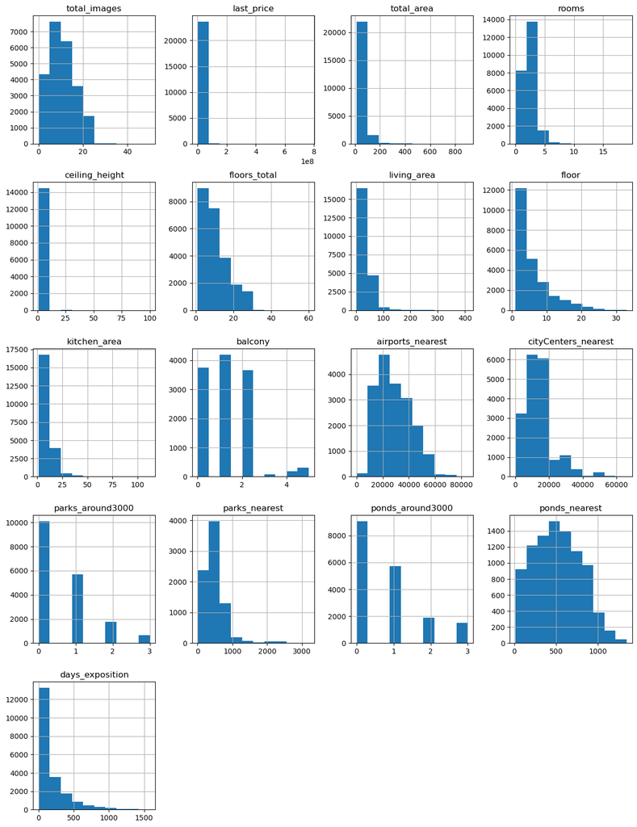

```python
data.hist(figsize=(15, 20)); # строим гистограмму для всех числовых столбцов таблицы
```

**Вывод шаг 1.3:** На гистограммах по каждому столбцу есть аномально низкие и высокие значения. Будем разбираться с каждым столбцом индивидуально. Данные столбцов: total_images, parks_around3000, ponds_around3000, ponds_nearest трогать не будем, т.к. они не участвуют в анализе.

## Шаг Предобработка данных

### Найдем и изучим пропущенные значения в столбцах:

- Определяем, в каких столбцах есть пропуски.
- Заполняем пропущенные значения там, где это возможно. Например, если продавец не указал число балконов, то, скорее всего, в его квартире их нет. Такие пропуски правильно заменить на 0. Если логичную замену предложить невозможно, то оставьте эти значения пустыми. Пропуски — тоже важный сигнал, который нужно учитывать.
- В ячейке с типом markdown укажем причины, которые могли привести к пропускам в данных.

```python
data.columns # в названиях столбцов не будем ничего менять
```

```
Index(['total_images', 'last_price', 'total_area', 'first_day_exposition', 'rooms', 'ceiling_height', 'floors_total', 'living_area', 'floor', 'is_apartment', 'studio', 'open_plan', 'kitchen_area', 'balcony', 'locality_name', 'airports_nearest', 'cityCenters_nearest', 'parks_around3000', 'parks_neare…
```

```python
data.isna().sum() # узнаем сколько в каждом столбце пропусков
```

```
total_images                0
last_price                  0
total_area                  0
first_day_exposition        0
rooms                       0
ceiling_height           9195
floors_total               86
living_area              1903
floor                       0
is_apartment            20924
studio                      0
open_plan                   0
kitchen_area             2278
balcony                 11519
locality_name              49
airports_nearest         5542
cityCenters_nearest      5519
parks_around3000         5518
parks_nearest           15620
ponds_around3000         5518
ponds_nearest           14589
days_exposition          3181
dtype: int64
```

```python
data.isna().mean()*100 # подсчитаем в процентном отношении пропуски в каждом столбце
```

```
total_images             0.000000
last_price               0.000000
total_area               0.000000
first_day_exposition     0.000000
rooms                    0.000000
ceiling_height          38.799105
floors_total             0.362885
living_area              8.029875
floor                    0.000000
is_apartment            88.290645
studio                   0.000000
open_plan                0.000000
kitchen_area             9.612220
balcony                 48.605426
locality_name            0.206760
airports_nearest        23.384953
cityCenters_nearest     23.287902
parks_around3000        23.283683
parks_nearest           65.909954
ponds_around3000        23.283683
ponds_nearest           61.559559
days_exposition         13.422507
dtype: float64
```

```python
data.describe() # посмотрим общую картину данных
```

|  | total_images | last_price | total_area | rooms | ceiling_height | floors_total | living_area | floor | kitchen_area | balcony | airports_nearest | cityCenters_nearest | parks_around3000 | parks_nearest | ponds_around3000 | ponds_nearest | days_exposition |
| --- | --- | --- | --- | --- | --- | --- | --- | --- | --- | --- | --- | --- | --- | --- | --- | --- | --- |
| count | 23699.000000 | 2.369900e+04 | 23699.000000 | 23699.000000 | 14504.000000 | 23613.000000 | 21796.000000 | 23699.000000 | 21421.000000 | 12180.000000 | 18157.000000 | 18180.000000 | 18181.000000 | 8079.000000 | 18181.000000 | 9110.000000 | 20518.000000 |
| mean | 9.858475 | 6.541549e+06 | 60.348651 | 2.070636 | 2.771499 | 10.673824 | 34.457852 | 5.892358 | 10.569807 | 1.150082 | 28793.672193 | 14191.277833 | 0.611408 | 490.804555 | 0.770255 | 517.980900 | 180.888634 |
| std | 5.682529 | 1.088701e+07 | 35.654083 | 1.078405 | 1.261056 | 6.597173 | 22.030445 | 4.885249 | 5.905438 | 1.071300 | 12630.880622 | 8608.386210 | 0.802074 | 342.317995 | 0.938346 | 277.720643 | 219.727988 |
| min | 0.000000 | 1.219000e+04 | 12.000000 | 0.000000 | 1.000000 | 1.000000 | 2.000000 | 1.000000 | 1.300000 | 0.000000 | 0.000000 | 181.000000 | 0.000000 | 1.000000 | 0.000000 | 13.000000 | 1.000000 |
| 25% | 6.000000 | 3.400000e+06 | 40.000000 | 1.000000 | 2.520000 | 5.000000 | 18.600000 | 2.000000 | 7.000000 | 0.000000 | 18585.000000 | 9238.000000 | 0.000000 | 288.000000 | 0.000000 | 294.000000 | 45.000000 |
| 50% | 9.000000 | 4.650000e+06 | 52.000000 | 2.000000 | 2.650000 | 9.000000 | 30.000000 | 4.000000 | 9.100000 | 1.000000 | 26726.000000 | 13098.500000 | 0.000000 | 455.000000 | 1.000000 | 502.000000 | 95.000000 |
| 75% | 14.000000 | 6.800000e+06 | 69.900000 | 3.000000 | 2.800000 | 16.000000 | 42.300000 | 8.000000 | 12.000000 | 2.000000 | 37273.000000 | 16293.000000 | 1.000000 | 612.000000 | 1.000000 | 729.000000 | 232.000000 |
| max | 50.000000 | 7.630000e+08 | 900.000000 | 19.000000 | 100.000000 | 60.000000 | 409.700000 | 33.000000 | 112.000000 | 5.000000 | 84869.000000 | 65968.000000 | 3.000000 | 3190.000000 | 3.000000 | 1344.000000 | 1580.000000 |

В данных есть аномальные значения. В некоторых столбцах есть пропуски. Будем выяснять причину их образования

#### Заполняем пропущенные значения в столбце is_apartment - апартаменты:

Пропуски в столбце апартаменты заполняем 0. Предполагаем что, если не заполнена строка, значит это не апартаменты.

```python
print('Количество NaN в столбце is_apartment:', data['is_apartment'].isnull().sum())
data['is_apartment'].value_counts()
```

```
Количество NaN в столбце is_apartment: 20924
```

```
False    2725
True       50
Name: is_apartment, dtype: int64
```

```python
data['is_apartment'] = data['is_apartment'].fillna(0)
print('Количество NaN в столбце is_apartment:', data['is_apartment'].isnull().sum())
```

```
Количество NaN в столбце is_apartment: 0
```

#### Заполняем пропущенные значения в столбце balcony - число балконов:

В столбце balcony пропуски заполняем 0, т.к. пропуски в столбце скорее всего означают отсутствие балконов.

```python
print('Количество NaN в столбце balcony:', data['balcony'].isnull().sum())
data['balcony'].value_counts()
```

```
Количество NaN в столбце balcony: 11519
```

```
1.0    4195
0.0    3758
2.0    3659
5.0     304
4.0     183
3.0      81
Name: balcony, dtype: int64
```

```python
data['balcony'] = data['balcony'].fillna(0)
print('Количество NaN в столбце balcony:', data['balcony'].isnull().sum())
```

```
Количество NaN в столбце balcony: 0
```

#### Заменяем пропуски в столбце living_area(жилая площадь) медианным значение:

```python
print('Медиана доли жилой площади:', round((data['living_area']/data['total_area']).median(),2))
```

```
Медиана доли жилой площади: 0.57
```

```python
data_total_living = round((data['living_area']/data['total_area']).median()*data['total_area'],2)
data['living_area'] = data['living_area'].fillna(value=data_total_living)
```

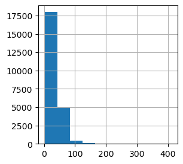

```python
# строим гистограмму
data['living_area'].hist(figsize=(3, 3));
```

#### Заменяем пропуски в столбце kitchen_area(площадь кухни) медианным значение:

```python
print('Медиана доли площади кухни:', round((data['kitchen_area']/data['total_area']).median(),2))
```

```
Медиана доли площади кухни: 0.17
```

```python
data_kitchen_total = round((data['kitchen_area']/data['total_area']).median()*data['total_area'],2)
data['kitchen_area'] = data['kitchen_area'].fillna(value=data_kitchen_total)
```

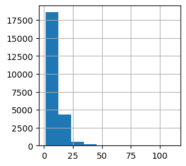

```python
# строим гистограмму
data['kitchen_area'].hist(figsize=(3, 3));
```

Заполнения столбцов:living_area и kitchen_area медианным значением не повлияло на данные.

#### Заменяем пропуски в столбце ceiling_height(высота потолков) медианным значение:

```python
print('Количество NaN в столбце ceiling_height:', data['ceiling_height'].isnull().sum())
data['ceiling_height'].value_counts()
```

```
Количество NaN в столбце ceiling_height: 9195
```

```
2.50      3515
2.60      1646
2.70      1574
3.00      1112
2.80       993
2.55       980
2.75       910
2.65       676
3.20       277
3.10       203
2.90       164
3.30       141
2.56       139
3.50       130
2.57       103
2.85       101
3.40        92
2.54        83
2.64        81
2.52        79
2.53        67
2.58        63
2.77        61
2.76        60
3.15        57
2.78        51
2.95        47
3.05        46
4.00        39
2.67        36
3.25        36
3.60        36
2.73        35
2.51        34
2.72        31
3.70        30
2.74        28
2.40        23
2.68        23
3.80        20
```

[output cut: 129 more lines]

```
5.50         1
3.87         1
3.42         1
3.83         1
3.43         1
4.30         1
3.39         1
3.98         1
4.65         1
5.00         1
2.20         1
2.34         1
3.93         1
3.59         1
Name: ceiling_height, dtype: int64
```

```python
data['ceiling_height'] = data['ceiling_height'].fillna(data['ceiling_height'].median())
print('Количество NaN в столбце ceiling_height:', data['ceiling_height'].isnull().sum())
```

```
Количество NaN в столбце ceiling_height: 0
```

**Вывод шаг 2.1.:** Нашли и заменили пропущенные значения в столбцах:is_apartment, balcony,living_area, kitchen_area, ceiling_height . В столбце is_apartment замениили пропуски 0 значением; в столбцах living_area, kitchen_area, ceiling_height заменили пропуски медианным значением.

### Рассмотрим типы данных в каждом столбце:

- Найдем столбцы, в которых нужно изменить тип данных.
- Преобразуем тип данных в выбранных столбцах.
- В ячейке с типом markdown поясним, почему нужно изменить тип данных.

#### Изменяем тип данных в столбце floors_total(всего этажей в доме):

```python
data = data.dropna(subset=['floors_total']) #удаляем 86 пустых значений - это 0,3% от всех данных
data = data.reset_index(drop=True)
data['floors_total'] = data['floors_total'].astype('Int64') #изменяем тип даннных с float, на int
```

#### Изменяем тип данных в столбце balcony(число балконов):

```python
data['balcony'] = data['balcony'].astype('Int64') #изменяем тип даннных с float, на int
```

#### Изменяем тип данных в столбце first_day_exposition(дата публикации):

```python
data['first_day_exposition'] = pd.to_datetime(data['first_day_exposition'], format = '%Y-%m-%d') #переведем столбец с датой в формат даты без времени, т.к. время не указано
```

#### Изменяем тип данных в столбце is_apartment(апартаменты):

```python
data['is_apartment'] = data['is_apartment'].astype('bool') # в данных указан булевый тип
```

```python
data.info()
```

```
<class 'pandas.core.frame.DataFrame'>
RangeIndex: 23613 entries, 0 to 23612
Data columns (total 22 columns):
 #   Column                Non-Null Count  Dtype
---  ------                --------------  -----
 0   total_images          23613 non-null  int64
 1   last_price            23613 non-null  float64
 2   total_area            23613 non-null  float64
 3   first_day_exposition  23613 non-null  datetime64[ns]
 4   rooms                 23613 non-null  int64
 5   ceiling_height        23613 non-null  float64
 6   floors_total          23613 non-null  Int64
 7   living_area           23613 non-null  float64
 8   floor                 23613 non-null  int64
 9   is_apartment          23613 non-null  bool
 10  studio                23613 non-null  bool
 11  open_plan             23613 non-null  bool
 12  kitchen_area          23613 non-null  float64
 13  balcony               23613 non-null  Int64
 14  locality_name         23565 non-null  object
 15  airports_nearest      18081 non-null  float64
 16  cityCenters_nearest   18104 non-null  float64
 17  parks_around3000      18105 non-null  float64
 18  parks_nearest         8045 non-null   float64
 19  ponds_around3000      18105 non-null  float64
 20  ponds_nearest         9061 non-null   float64
 21  days_exposition       20441 non-null  float64
dtypes: Int64(2), bool(3), datetime64[ns](1), float64(12), int64(3), object(1)
memory usage: 3.5+ MB
```

### Изучим уникальные значения в столбце с названиями и устраним неявные дубликаты.

Например, «поселок Рябово» и «поселок городского типа Рябово», «поселок Тельмана» и «посёлок Тельмана» — это обозначения одних и тех же населённых пунктов. Вы можете заменить названия в существующем столбце или создать новый с названиями без дубликатов.

```python
data['locality_name'].sort_values().unique() #сортируем данные в столбце locality_name по уникальным значениям
```

```
array(['Бокситогорск', 'Волосово', 'Волхов', 'Всеволожск', 'Выборг',
       'Высоцк', 'Гатчина', 'Зеленогорск', 'Ивангород', 'Каменногорск',
       'Кингисепп', 'Кириши', 'Кировск', 'Колпино', 'Коммунар',
       'Красное Село', 'Кронштадт', 'Кудрово', 'Лодейное Поле',
       'Ломоносов', 'Луга', 'Любань', 'Мурино', 'Никольское',
       'Новая Ладога', 'Отрадное', 'Павловск', 'Петергоф', 'Пикалёво',
       'Подпорожье', 'Приморск', 'Приозерск', 'Пушкин', 'Санкт-Петербург',
       'Светогорск', 'Сертолово', 'Сестрорецк', 'Сланцы', 'Сосновый Бор',
       'Сясьстрой', 'Тихвин', 'Тосно', 'Шлиссельбург',
       'городской поселок Большая Ижора', 'городской поселок Янино-1',
       'городской посёлок Будогощь', 'городской посёлок Виллози',
       'городской посёлок Лесогорский', 'городской посёлок Мга',
       'городской посёлок Назия', 'городской посёлок Новоселье',
       'городской посёлок Павлово', 'городской посёлок Рощино',
       'городской посёлок Свирьстрой', 'городской посёлок Советский',
       'городской посёлок Фёдоровское', 'городской посёлок Янино-1',
       'деревня Агалатово', 'деревня Аро', 'деревня Батово',
       'деревня Бегуницы', 'деревня Белогорка', 'деревня Большая Вруда',
       'деревня Большая Пустомержа', 'деревня Большие Колпаны',
       'деревня Большое Рейзино', 'деревня Большой Сабск', 'деревня Бор',
       'деревня Борисова Грива', 'деревня Ваганово', 'деревня Вартемяги',
       'деревня Вахнова Кара', 'деревня Выскатка', 'деревня Гарболово',
       'деревня Глинка', 'деревня Горбунки', 'деревня Гостилицы',
       'деревня Заклинье', 'деревня Заневка', 'деревня Зимитицы',
       'деревня Извара', 'деревня Иссад', 'деревня Калитино',
       'деревня Кальтино', 'деревня Камышовка', 'деревня Каськово',
       'деревня Келози', 'деревня Кипень', 'деревня Кисельня',
       'деревня Колтуши', 'деревня Коркино', 'деревня Котлы',
       'деревня Кривко', 'деревня Кудрово', 'деревня Кузьмолово',
       'деревня Курковицы', 'деревня Куровицы', 'деревня Куттузи',
       'деревня Лаврики', 'деревня Лаголово', 'деревня Лампово',
       'деревня Лесколово', 'деревня Лопухинка', 'деревня Лупполово',
       'деревня Малая Романовка', 'деревня Малое Верево',
       'деревня Малое Карлино', 'деревня Малые Колпаны',
       'деревня Мануйлово', 'деревня Меньково', 'деревня Мины',
       'деревня Мистолово', 'деревня Ненимяки', 'деревня Нижние Осельки',
       'деревня Нижняя', 'деревня Низино', 'деревня Новое Девяткино',
       'деревня Новолисино', 'деревня Нурма', 'деревня Оржицы',
       'деревня Парицы', 'деревня Пельгора', 'деревня Пеники',
       'деревня Пижма', 'деревня Пикколово', 'деревня Пудомяги',
```

[output cut: 96 more lines]

```
       'посёлок городского типа Тайцы', 'посёлок городского типа Токсово',
       'посёлок городского типа Ульяновка',
       'посёлок городского типа Форносово',
       'посёлок городского типа имени Морозова',
       'посёлок городского типа имени Свердлова',
       'посёлок при железнодорожной станции Вещево',
       'посёлок при железнодорожной станции Приветнинское',
       'посёлок станции Громово', 'посёлок станции Свирь',
       'садоводческое некоммерческое товарищество Лесная Поляна',
       'садовое товарищество Новая Ропша',
       'садовое товарищество Приладожский', 'садовое товарищество Рахья',
       'садовое товарищество Садко', 'село Копорье', 'село Никольское',
       'село Павлово', 'село Паша', 'село Путилово', 'село Рождествено',
       'село Русско-Высоцкое', 'село Старая Ладога', 'село Шум', nan],
      dtype=object)
```

```python
data['locality_name'].value_counts()  #выводим данные в столбце locality_name по количеству значений
```

```
Санкт-Петербург                                            15651
посёлок Мурино                                               520
посёлок Шушары                                               439
Всеволожск                                                   398
Пушкин                                                       369
Колпино                                                      338
посёлок Парголово                                            327
Гатчина                                                      307
деревня Кудрово                                              299
Выборг                                                       237
Петергоф                                                     201
Сестрорецк                                                   183
Красное Село                                                 176
Кудрово                                                      171
деревня Новое Девяткино                                      143
Сертолово                                                    142
Ломоносов                                                    133
Кириши                                                       125
Сланцы                                                       112
Волхов                                                       111
Кингисепп                                                    104
Тосно                                                        104
Кронштадт                                                     96
Никольское                                                    93
Коммунар                                                      89
Сосновый Бор                                                  87
Кировск                                                       84
Отрадное                                                      80
посёлок Бугры                                                 68
Приозерск                                                     66
посёлок Металлострой                                          66
деревня Старая                                                64
городской посёлок Янино-1                                     61
Шлиссельбург                                                  57
Луга                                                          56
Тихвин                                                        49
поселок Бугры                                                 45
посёлок Стрельна                                              43
посёлок Тельмана                                              39
Павловск                                                      38
```

[output cut: 310 more lines]

```
деревня Ялгино                                                 1
посёлок Форт Красная Горка                                     1
деревня Сижно                                                  1
деревня Котлы                                                  1
посёлок при железнодорожной станции Вещево                     1
деревня Щеглово                                                1
посёлок Алексеевка                                             1
посёлок Белоостров                                             1
деревня Пельгора                                               1
поселок Каложицы                                               1
посёлок Платформа 69-й километр                                1
поселок Почап                                                  1
поселок Гончарово                                              1
посёлок Дзержинского                                           1
Name: locality_name, dtype: int64
```

```python
data['locality_name'] = data['locality_name'].fillna('unknown') # заполняем пропуски специальным значением unknown
```

```python
data['locality_name'] = data['locality_name'].map(lambda x: x.replace('ё', 'е')) # меняем в словах с буквой ё на букву е
```

```python
# data[data['locality_name'].str.contains(r'\b  ')] # проверяем в названиях на неявные дубликаты
```

Исправляем в названиях неявные дубликаты

```python
data['locality_name'] = data['locality_name'].replace(['поселок Рябово', 'посёлок городского типа Рябово'], 'поселок городского типа Рябово')
```

```python
data['locality_name'] = data['locality_name'].replace(['деревня Кудрово'], 'Кудрово')
```

```python
data['locality_name'] = data['locality_name'].replace(['городской поселок Лесогорский', 'поселок городского типа Лесогорский\t'], 'поселок городского типа Лесогорский')
```

```python
data['locality_name'] = data['locality_name'].replace(['городской поселок Павлово'], 'поселок городского типа Павлово')
```

```python
data['locality_name'] = data['locality_name'].replace(['городской поселок Будогощь'], 'поселок городского типа Будогощь')
```

```python
data['locality_name'] = data['locality_name'].replace(['городской поселок Большая Ижора'], 'поселок городского типа Большая Ижора')
```

```python
data['locality_name'] = data['locality_name'].replace(['поселок городского типа Мга'], 'городской поселок Мга')
```

```python
data['locality_name'] = data['locality_name'].replace(['городской поселок Назия'], 'поселок городского типа Назия')
```

```python
data['locality_name'] = data['locality_name'].replace(['городской поселок Рощино'], 'поселок городского типа Рощино')
```

```python
data['locality_name'] = data['locality_name'].replace(['городской поселок Свирьстрой'], 'поселок городского типа Свирьстрой')
```

```python
data['locality_name'] = data['locality_name'].replace(['городской поселок Советский'], 'поселок городского типа Советский')
```

```python
data['locality_name'] = data['locality_name'].replace(['деревня Федоровское'], 'городской поселок Федоровское')
```

```python
data['locality_name'] = data['locality_name'].replace(['городской поселок Янино-1'], 'поселок городского типа Янино-1')
```

```python
data['locality_name'].value_counts()  #проверяем данные в столбце locality_name после исправления
```

```
Санкт-Петербург                                            15651
поселок Мурино                                               552
Кудрово                                                      470
поселок Шушары                                               439
Всеволожск                                                   398
Пушкин                                                       369
Колпино                                                      338
поселок Парголово                                            327
Гатчина                                                      307
Выборг                                                       237
Петергоф                                                     201
Сестрорецк                                                   183
Красное Село                                                 176
деревня Новое Девяткино                                      143
Сертолово                                                    142
Ломоносов                                                    133
Кириши                                                       125
поселок Бугры                                                113
Сланцы                                                       112
Волхов                                                       111
Кингисепп                                                    104
Тосно                                                        104
Кронштадт                                                     96
Никольское                                                    93
Коммунар                                                      89
Сосновый Бор                                                  87
Кировск                                                       84
Отрадное                                                      80
поселок городского типа Янино-1                               68
поселок Металлострой                                          66
Приозерск                                                     66
деревня Старая                                                64
Шлиссельбург                                                  57
Луга                                                          56
Тихвин                                                        49
unknown                                                       48
поселок Стрельна                                              43
поселок Тельмана                                              41
поселок городского типа Рощино                                39
Павловск                                                      38
```

[output cut: 267 more lines]

```
поселок Семиозерье                                             1
деревня Тойворово                                              1
деревня Зимитицы                                               1
деревня Реброво                                                1
коттеджный поселок Счастье                                     1
поселок городского типа Кондратьево                            1
деревня Мануйлово                                              1
деревня Пчева                                                  1
деревня Курковицы                                              1
поселок Цвылево                                                1
деревня Кривко                                                 1
поселок Жилпоселок                                             1
поселок Тесово-4                                               1
поселок Дзержинского                                           1
Name: locality_name, dtype: int64
```

**Выводы шаг 2 .3.:** Изучили уникальные значения в столбце locality_name с названиями и устранили неявные дубликаты.

### Найдем и устраним редкие и выбивающиеся значения.

Например, в столбце ceiling_height может быть указана высота потолков 25 м и 32 м. Логично предположить, что на самом деле это вещественные значения: 2.5 м и 3.2 м. Попробуйте обработать аномалии в этом и других столбцах.

- Если природа аномалии понятна и данные действительно искажены, то восстановим корректное значение.
- В противном случае удалим редкие и выбивающиеся значения.
- В ячейке с типом markdown опишем, какие особенности в данных вы обнаружили.

#### Обрабатываем аномальные значения столбца ceiling_height(высота потолков):

```python
data['ceiling_height'].sort_values().unique() #сортируем данные в столбце ceiling_height по уникальным значениям
```

```
array([  1.  ,   1.2 ,   1.75,   2.  ,   2.2 ,   2.25,   2.3 ,   2.34,
         2.4 ,   2.45,   2.46,   2.47,   2.48,   2.49,   2.5 ,   2.51,
         2.52,   2.53,   2.54,   2.55,   2.56,   2.57,   2.58,   2.59,
         2.6 ,   2.61,   2.62,   2.63,   2.64,   2.65,   2.66,   2.67,
         2.68,   2.69,   2.7 ,   2.71,   2.72,   2.73,   2.74,   2.75,
         2.76,   2.77,   2.78,   2.79,   2.8 ,   2.81,   2.82,   2.83,
         2.84,   2.85,   2.86,   2.87,   2.88,   2.89,   2.9 ,   2.91,
         2.92,   2.93,   2.94,   2.95,   2.96,   2.97,   2.98,   2.99,
         3.  ,   3.01,   3.02,   3.03,   3.04,   3.05,   3.06,   3.07,
         3.08,   3.09,   3.1 ,   3.11,   3.12,   3.13,   3.14,   3.15,
         3.16,   3.17,   3.18,   3.2 ,   3.21,   3.22,   3.23,   3.24,
         3.25,   3.26,   3.27,   3.28,   3.29,   3.3 ,   3.31,   3.32,
         3.33,   3.34,   3.35,   3.36,   3.37,   3.38,   3.39,   3.4 ,
         3.42,   3.43,   3.44,   3.45,   3.46,   3.47,   3.48,   3.49,
         3.5 ,   3.51,   3.52,   3.53,   3.54,   3.55,   3.56,   3.57,
         3.58,   3.59,   3.6 ,   3.62,   3.63,   3.65,   3.66,   3.67,
         3.68,   3.69,   3.7 ,   3.75,   3.76,   3.78,   3.8 ,   3.82,
         3.83,   3.84,   3.85,   3.86,   3.87,   3.88,   3.9 ,   3.93,
         3.95,   3.98,   4.  ,   4.06,   4.1 ,   4.14,   4.15,   4.19,
         4.2 ,   4.25,   4.3 ,   4.37,   4.4 ,   4.45,   4.5 ,   4.65,
         4.7 ,   4.8 ,   4.9 ,   5.  ,   5.2 ,   5.3 ,   5.5 ,   5.6 ,
         5.8 ,   6.  ,   8.  ,   8.3 ,  10.3 ,  14.  ,  20.  ,  22.6 ,
        24.  ,  25.  ,  26.  ,  27.  ,  27.5 ,  32.  , 100.  ])
```

```python
data['ceiling_height'] = data['ceiling_height'].map(lambda x: x/10 if x>=11 else x if x<=5 else x/2) # изменяем аномальные значения
```

```python
data = data.loc[(data['ceiling_height'] != 10.) & (data['ceiling_height'] != 1.) & (data['ceiling_height'] != 1.2) & (data['ceiling_height'] != 1.4) & (data['ceiling_height'] != 1.75)]
# оставляем в столбце высоту потолков от 2 м до 5,15 м
```

```
count    23608.000000
mean         2.696515
std          0.217347
min          2.000000
25%          2.600000
50%          2.650000
75%          2.700000
max          5.150000
Name: ceiling_height, dtype: float64
```

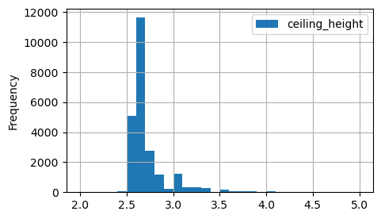

```python
data.plot(y = 'ceiling_height', kind = 'hist', bins = 30, range = (2,5), grid=True, figsize = (5,3));
data['ceiling_height'].describe()
```

#### Обрабатываем аномальные значения столбца last_price(цена на момент снятия с публикации):

```python
#data['last_price'] = data['last_price']
data['last_price'].shape
```

```
(23608,)
```

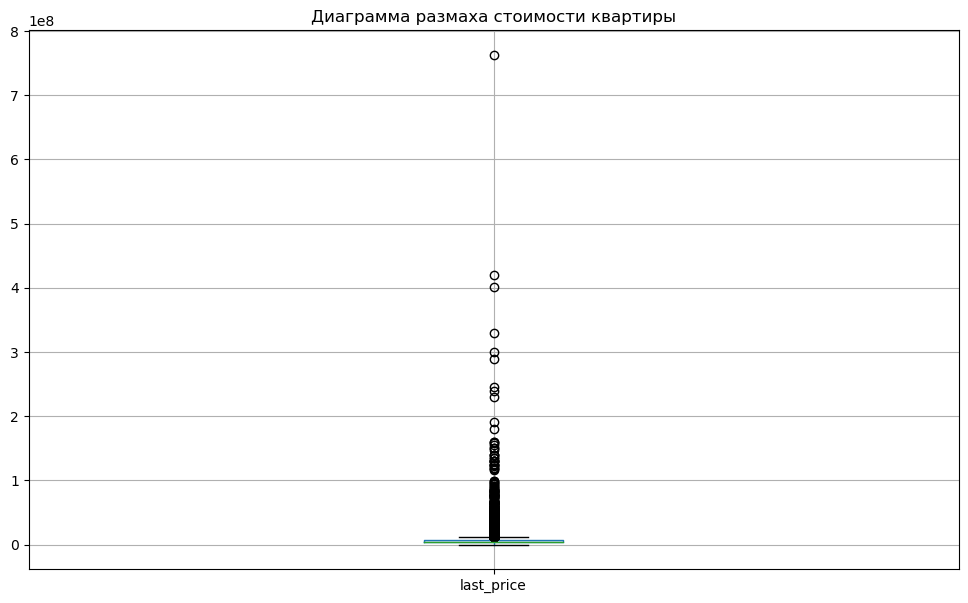

```python
data.boxplot(column='last_price', figsize=(12, 7))
plt.title('Диаграмма размаха стоимости квартиры')
plt.show()
```

```python
data['last_price'].min()
```

```
12190.0
```

```python
data['last_price'].max()
```

```
763000000.0
```

```python
data_new = data[(data['last_price'] > 12190) & (data['last_price'] <= 15000000 )] # убираем анамальные значения
```

```python
data['last_price'].shape
```

```
(23608,)
```

```python
data_new['last_price'].shape
```

```
(22408,)
```

```python
round(100 -(data_new.shape[0] / data.shape[0])*100, 2) # 5.08% данных удаляем
```

```
5.08
```

```python
data = data[(data['last_price'] > 12190 ) & (data['last_price'] <= 15000000)]
```

```
count    2.240800e+04
mean     5.159152e+06
std      2.712898e+06
min      4.300000e+05
25%      3.369750e+06
50%      4.500000e+06
75%      6.300000e+06
max      1.500000e+07
Name: last_price, dtype: float64
```

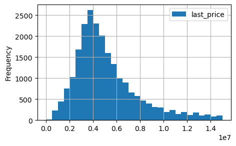

```python
data.plot(y = 'last_price', kind = 'hist', bins = 30, range = (2,15000000), grid=True, figsize = (5,3))
data['last_price'].describe()
```

#### Обрабатываем аномальные значения столбца rooms (число комнат):

```python
data['rooms'].shape
```

```
(22408,)
```

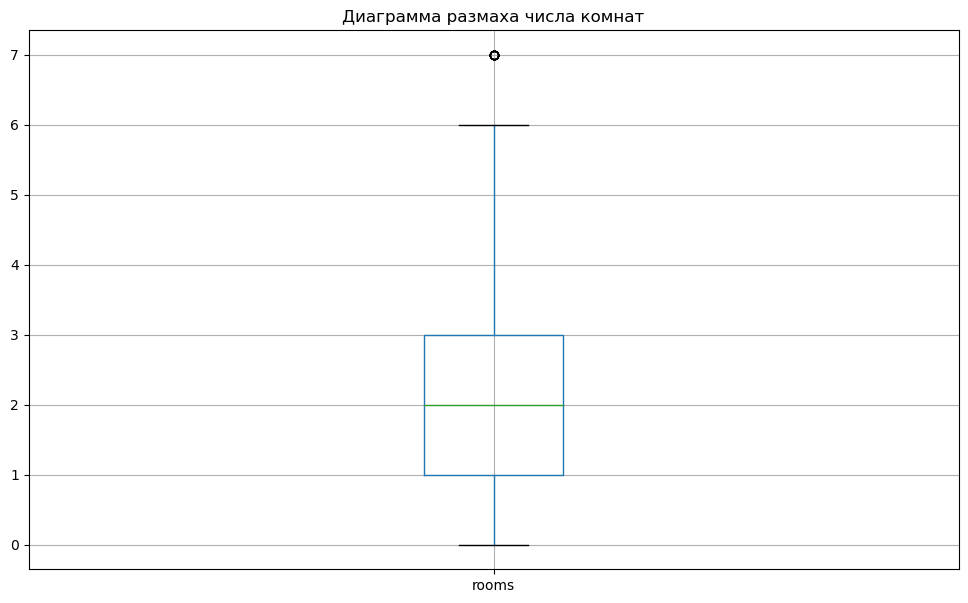

```python
data.boxplot(column='rooms', figsize=(12, 7))
plt.title('Диаграмма размаха числа комнат')
plt.show()
```

```python
data['rooms'].min()
```

```
0
```

```python
data['rooms'].max()
```

```
7
```

```python
data_new = data[(data['rooms'] > 0) & (data['rooms'] < 7)] # убираем анамальные значения
```

```python
data['last_price'].shape
```

```
(22408,)
```

```python
data_new['last_price'].shape
```

```
(22206,)
```

```python
round(100 -(data_new.shape[0] / data.shape[0])*100, 2) # 0.9% данных удаляем
```

```
0.9
```

```python
data = data[(data['rooms'] > 0) & (data['rooms'] < 7)]
```

```
count    22206.000000
mean         1.993470
std          0.929636
min          1.000000
25%          1.000000
50%          2.000000
75%          3.000000
max          6.000000
Name: rooms, dtype: float64
```

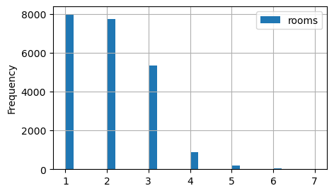

```python
data.plot(y = 'rooms', kind = 'hist', bins = 30, range = (1,7), grid=True, figsize = (5,3))
data['rooms'].describe()
```

Нашли и устранили редкие и выбивающиеся значения в столбце rooms. Теперь данные стали корректными: медиана(2,00) близка к среднему(1,99) значению, значит большого разброса(выбросов) в данных нет. Минимальное значение - 1, максимальное значение - 6.

#### Обрабатываем аномальные значения столбца total_area (общая площадь квартиры):

```python
data['total_area'].shape
```

```
(22206,)
```

```python
data['total_area'].describe()
```

```
count    22206.000000
mean        55.402330
std         21.743457
min         12.000000
25%         40.000000
50%         50.580000
75%         66.000000
max        320.000000
Name: total_area, dtype: float64
```

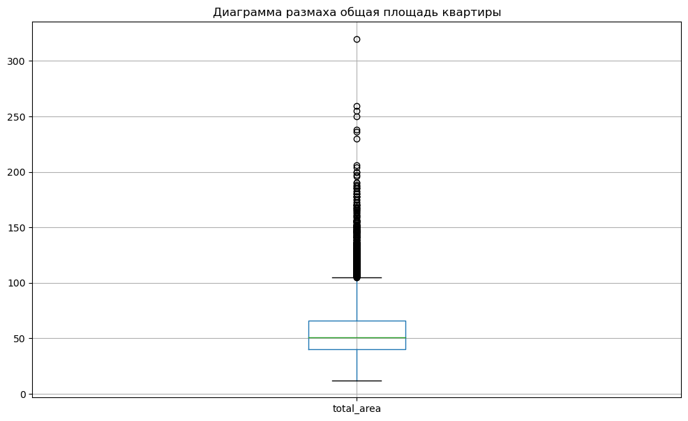

```python
data.boxplot(column='total_area', figsize=(12, 7))
plt.title('Диаграмма размаха общая площадь квартиры')
plt.show()
```

```python
data['total_area'].min()
```

```
12.0
```

```python
data['total_area'].max()
```

```
320.0
```

```python
data_new = data[(data['total_area'] > 20) & (data['total_area'] <= 110)] # убираем анамальные значения
```

```python
data['total_area'].shape
```

```
(22206,)
```

```python
data_new['total_area'].shape
```

```
(21691,)
```

```python
round(100 -(data_new.shape[0] / data.shape[0])*100, 2) # 2.32% данных удаляем
```

```
2.32
```

```python
data = data[(data['total_area'] > 20) & (data['total_area'] <= 110)]
```

```
count    21691.000000
mean        53.711030
std         18.225243
min         20.100000
25%         39.565000
50%         50.000000
75%         64.600000
max        110.000000
Name: total_area, dtype: float64
```

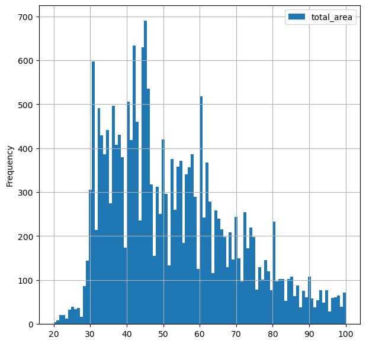

```python
data.plot(y = 'total_area', kind = 'hist', bins = 100, range = (20,100), grid=True, figsize = (7,7))
data['total_area'].describe()
```

## Шаг Добавим в таблицу новые столбцы со следующими параметрами:

- цена одного квадратного метра;
- день недели публикации объявления (0 — понедельник, 1 — вторник и так далее);
- месяц публикации объявления;
- год публикации объявления;
- тип этажа квартиры (значения — «первый», «последний», «другой»);
- расстояние до центра города в километрах (переведите из м в км и округлите до целых значений).

### Расcчитываем цену одного квадратного метра

```python
data['price_meter'] = data['last_price'] / data['total_area']
```

### Рассчитываем день недели публикации объявления (0 — понедельник, 1 — вторник и так далее)

#### Создаем новые столбцы weekday(день), month(месяц), year(год):

```python
#создаю столбец дня недели
data['weekday'] = pd.DatetimeIndex(data['first_day_exposition']).weekday

#создаю столбец месяца
data['month'] = pd.DatetimeIndex(data['first_day_exposition']).month

#создаю столбец года
data['year'] = pd.DatetimeIndex(data['first_day_exposition']).year
```

```python
data['weekday'].sort_values().unique() #узнаем сколько уникальных данных в столбце weekday
```

```
array([0, 1, 2, 3, 4, 5, 6], dtype=int64)
```

#### Создаем функцию для разбивки публикации обьявления по дням неделям:

```python
def day_publication(day):
    try:
        if day == 0:
            return 'понедельник'
        elif day == 1:
            return 'вторник'
        elif day == 2:
            return 'среда'
        elif day == 3:
            return 'четверг'
        elif day == 4:
            return 'пятница'
        elif day == 5:
            return 'суббота'
        elif day == 6:
            return 'воскресенье'
    except:
        pass
data['day_publication'] = data['weekday'].apply(day_publication)
```

#### Создаем функцию для разбивки публикации обьявления по месяц:

```python
data['month'].sort_values().unique() #узнаем сколько уникальных данных в столбце month
```

```
array([ 1,  2,  3,  4,  5,  6,  7,  8,  9, 10, 11, 12], dtype=int64)
```

```python
def month_publication(month):
    try:
        if month == 1:
            return 'январь'
        elif month == 2:
            return 'февраль'
        elif month == 3:
            return 'март'
        elif month == 4:
            return 'апрель'
        elif month == 5:
            return 'май'
        elif month == 6:
            return 'июнь'
        elif month == 7:
            return 'июль'
        elif month == 8:
            return 'август'
        elif month == 9:
            return 'сентябрь'
        elif month == 10:
            return 'октябрь'
        elif month == 11:
            return 'ноябрь'
        elif month == 12:
            return 'декабрь'
    except:
        pass
data['month_publication'] = data['month'].apply(month_publication)
```

#### Создаем функцию для разбивки по типу этажа квартиры (значения — «первый», «последний», «другой»):

```python
data['floor'].sort_values().unique() #узнаем сколько уникальных данных в столбце floor
```

```
array([ 1,  2,  3,  4,  5,  6,  7,  8,  9, 10, 11, 12, 13, 14, 15, 16, 17,
       18, 19, 20, 21, 22, 23, 24, 25, 26, 27, 28, 29, 30, 31, 32, 33],
      dtype=int64)
```

```python
data['floors_total'].sort_values().unique() #узнаем сколько уникальных данных в столбце floors_total
```

```
<IntegerArray>
[1, 2, 3, 4, 5, 6, 7, 8, 9, 10, 11, 12, 13, 14, 15, 16, 17, 18, 19, 20, 21, 22, 23, 24, 25, 26, 27, 28, 29, 33, 34, 35, 36, 52, 60]
Length: 35, dtype: Int64
```

```python
def floor_category(row):
    try:
        floors_total = row['floors_total']
        floor = row['floor']
        if floor ==1:
            return 'первый'
        elif floor == floors_total:
            return 'последний'
        elif 1 < floor < floors_total:
            return 'другой'
    except:
        pass
data['floor_category'] = data.apply(floor_category, axis = 1)
```

#### Рассчитываем расстояние до центра города в километрах в столбце cityCenters_nearest(переведите из м в км и округлите до целых значений).

```python
data['cityCenters_nearest'] = data['cityCenters_nearest']/1000 #переводим метры в километры в столбце cityCenters_nearest
```

```python
data['cityCenters_nearest'] = np.floor(pd.to_numeric(data['cityCenters_nearest'], errors='coerce')).astype('Int64') # переводим в тип данных int
```

**Выводы шаг 3**: Создали и рассчитали новые столбцы price_meter(цена одного м2) , weekday(день), month(месяц), year(год), day_publication (день недели публикации объявления), month_publication (месяц публикации объявления), floor_category (тип этажа квартиры); перевели из м в км и округлили до целого значения расстояние до центра города.